# Chapter 18 — Practice Challenge Solutions

←Back to the bookChapter 18 · Take the quiz & aim for 100%

Chapter 18 · Solutions

Practice Challenges, Worked Answers ✅

Full solutions to the five "Data-Cleaning Mindset" challenges. Try them yourself first, then compare.

Statistics, Data Science and AI: A Visual Handbook · John Fisher · 2026

## ⚙️ Setup

```python
import numpy as np
import pandas as pd
print("Ready.")
```

```
Ready.
```

CHALLENGE 1 · WRONG TYPES

Spot the misread columns

This frame has prices and quantities that won't do math. Use info()/dtypes to find which columns are stored as text instead of numbers, and explain why that happens on import.

```python
df = pd.DataFrame({"item":["A","B","C"], "price":["1,200","350","2,000"], "qty":["10","4","7"]})
print(df.dtypes)
print("\nTrying price.mean():")
try:
    print(df["price"].mean())
except Exception as e:
    print("  ERROR:", type(e).__name__)
```

```
item     str
price    str
qty      str
dtype: object

Trying price.mean():
  ERROR: TypeError
```

**Answer:** Both **price** and **qty** are `object` (text), not numbers. `price` carries thousands **commas** (`"1,200"`), so a CSV reader keeps it as a string; `qty` may have been read as text for similar formatting reasons. Numbers stored as text silently break arithmetic and sorting. The fix (next chapters) is to strip the commas and convert with `pd.to_numeric`, but first you have to **notice** via `dtypes`.

CHALLENGE 2 · HIDDEN MISSING

The sentinel isna() misses

A temperature column uses -999 to mean "sensor offline." Count how many readings are really missing, and show how the naive mean is corrupted.

```python
temp = pd.Series([21.4, 22.0, -999, 20.8, -999, 23.1, 19.9])
print(f"isna() count        : {temp.isna().sum()}   (sees nothing!)")
print(f"hidden -999 count   : {(temp==-999).sum()}")
print(f"naive mean          : {temp.mean():.1f}   <- corrupted")
print(f"mean ignoring -999  : {temp[temp!=-999].mean():.1f}")
```

```
isna() count        : 0   (sees nothing!)
hidden -999 count   : 2
naive mean          : -270.1   <- corrupted
mean ignoring -999  : 21.4
```

CHALLENGE 3 · CATEGORY TANGLE

Count the real categories

A country column mixes spellings and casing. Use value_counts() to surface them, then count how many TRUE categories there really are.

```python
country = pd.Series(["USA","usa","U.S.A.","United States","UK","uk","U.K.","USA"])
print(country.value_counts())
print(f"\ndistinct labels: {country.nunique()}  but real countries: 2 (USA and UK)")
```

```
USA              2
usa              1
U.S.A.           1
United States    1
UK               1
uk               1
U.K.             1
Name: count, dtype: int64

distinct labels: 7  but real countries: 2 (USA and UK)
```

**Answer:** `value_counts()` shows several labels (USA, usa, U.S.A., United States, UK, uk, U.K.) that collapse to just **2 real categories**. Inconsistent casing and punctuation fragment one country into many, which would split counts and break group-bys. Standardizing these is Chapter 19; the mindset here is to **surface** them first.

CHALLENGE 4 · DUPES & RANGES

Two fast audits

Find exact duplicate rows and any impossible ages (outside 0 to 120) in this small table.

```python
df = pd.DataFrame({
    "id":[1,2,2,4,5],
    "name":["Ann","Bo","Bo","Cy","Di"],
    "age":[31, 27, 27, 250, 44],
})
print(f"exact duplicate rows: {df.duplicated().sum()}")
bad = df[(df["age"]<0)|(df["age"]>120)]
print(f"impossible ages     : {list(bad['age'])}")
```

```
exact duplicate rows: 1
impossible ages     : [250]
```

**Answer:** There is **1** exact duplicate row (the second "Bo, 27"), and one **impossible age** of 250. `duplicated()` flags repeated rows; a simple range rule flags values that cannot be real. Whether to drop the duplicate or investigate the 250 is a judgment call for later, the audit just makes them visible.

CHALLENGE 5 · TIDY IT UP

Reshape messy-wide to tidy-long

This sales table has years as COLUMN HEADERS, which breaks Wickham's first tidy rule (column headers are values, not variable names). Identify the broken rule and reshape it to tidy form with pd.melt.

```python
wide = pd.DataFrame({"store":["North","South"], "2021":[120,90], "2022":[135,110], "2023":[150,95]})
print("MESSY (years are column headers):"); print(wide)
tidy = wide.melt(id_vars="store", var_name="year", value_name="sales")
print("\nTIDY (each variable a column, each observation a row):"); print(tidy)
```

```
MESSY (years are column headers):
   store  2021  2022  2023
0  North   120   135   150
1  South    90   110    95

TIDY (each variable a column, each observation a row):
   store  year  sales
0  North  2021    120
1  South  2021     90
2  North  2022    135
3  South  2022    110
4  North  2023    150
5  South  2023     95
```

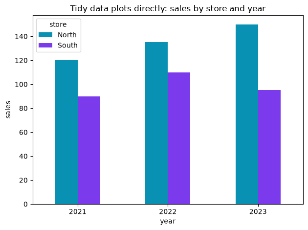

```python
import matplotlib.pyplot as plt
tidy.pivot(index="year", columns="store", values="sales").plot(kind="bar", color=["#0891b2", "#7c3aed"])
plt.title("Tidy data plots directly: sales by store and year"); plt.ylabel("sales")
plt.xticks(rotation=0); plt.tight_layout(); plt.show()
```

**Answer:** The years 2021, 2022, 2023 are **values, not variable names**, so the wide table breaks tidy rule 1 ("each variable forms a column"). `pd.melt` pulls them into a single **year** column with a matching **sales** column, so every row is now one observation (a store-year). Tidy data is about **shape**, not typos, and it is what lets grouping, plotting, and modeling just work.

🎉 Nicely done!

You caught misread types, unmasked a hidden missing code, collapsed a category tangle, flagged duplicates and impossible values, and reshaped messy-wide data into tidy-long form. That is the cleaning mindset: inspect first, never trust data you have not audited.

Statistics, Data Science and AI: A Visual Handbook · © 2026 John Fisher

←Back to the bookChapter 18 · Take the quiz & aim for 100%